# 1. Data Rich vs Data Poor

According to the nature of the data available for fisheries assessments there are two scenarios, those with plenty of data or data-rich and those with very limited details about the underlying stock to study, so-called data-poor or data-limited assessments.

[figure not shown]

## 1.1 Data-rich assessments

1. **Total catch** of the fisheries under study
2. Fish's hard-part analysis such as otoliths to estimate age, therefore an **age-based evaluation model** is possible.
3. Ability to identify and follow cohorts
4. In some occasions, **scientific surveys** are available to correct potential vias arising from fishery-dependent data. For example, large parts of the stocks could be confined in a specific area given the impression that there is much more fish available to catch than what there is actually.

The return on investement (ROI) is that results are **at scale** and are representative of the stock per se. For example, the total **spawning stock biomass** available year after year would be in tons.

## 1.2 Data-poor assessments

1. **Individual lengths** obtained from random surveys taking place on board of vessels or at port.
2. Sometimes total catch of of the **surveyed hauls** are available, so a **relative index of abudance** may be construted.
3. knowledge of the parameters of the **growth equations**, usually Von Bertalanffy.

Such a lack of data allows only to establish a series of indicators to evaluate the health of stock. We do not have informaton at scale but **indicative ratios**

# 2. Study case: small-scale fisheries in Galicia within a data-poor context

[figure not shown]

## 2.1 Small-scale fishery highlights

1. **~4K** vessels < 12m
2. **Great variety of fishing gears**: drifting nets, surface and bottom long lines, creels and some artisanal trawling
3. **20 different species** (teleosts, elamobranchs, molusks and crustanceans)
4. **Fishery-dependent data:** fisheries observers taken note of lengths and weight of some individuals of the random haul assigned to them as well as the total catch

[figure not shown]

## 2.2 Pipeline developed for the assessments fisheries

1. With total catches per hauls => A relative index of abundance
2. With lengths and weights of individuals => Length Based Methods **(LBMs)**
   - WKLIFE ICES recommendation: Length Based Indicators **(LBI)** and Length-Based Spawning Potential Ratio **(LBSPR)**, both assuming *equilibrium conditions* (Recruitment and Z are constant)
   - Non equilibrium conditions: Length-based Integrated Mixed Effects **(LIME)**

# 3. Overview of LBMs

The three methods have some requirements and assumptions and yield different indicators from which we have selected only the few we have an interest in, as shown in the table below:

[figure not shown]

- (*) Von Bertalanffy growth model for LBSPR and LIME is assumed and Life History Traits (LHTs) must be representative of the socks being studied
- 1: Hordyk et al. (2015) ICES Journal of Marine Science, 72; 2: Rudd, n.d. (2017) Accounting for Variability and Biases in Data-limited Fisheries Stock Assessment (dissertation); 3: ICES WKLIFE V REPORT 2015

## 3.1 Details of parameters

1. **L<sub>inf</sub>**: asymptotic length assuming Von Bertalanffy equation ($L_{t}=L_{inf}(1-\exp^{(-k(t-t_{0})}))$).
2. **k**: growth coefficient rate of the Von Bertalanffy equation.
3. **t<sub>0</sub>**: intercept of the Von Bertalanffy curve with the 'y' axis.

Theoretical age at size 0.

4. **L<sub>50</sub>**: length of first sexual maturity assuming a logistic curve.
5. **L<sub>95</sub>**: length at which 95% of individuals are mature.
6. **L<sub>wa</sub>**: parameter 'a' in the Length-Weight relationship equation ($W = aL^{b}$).
7. **L<sub>wb</sub>**: parameter 'b' in the Length-Weight relationship equation.
8. **M**: constant natural mortality across all cohorts and years.
9. **R<sub>var</sub>**: recruitment variability.
10. **F<sub>var</sub>**: fishing mortality varibility to cap inter-annual variation.
11. **M/K**: Beverton-Holt Life History Invariant (BH-LHIs) that Pauly defined as ~ 1.5 as a rule of thumb for teleosts (Prince et al., 2015).

Likewise, an explanation for the outputs of each algorithm is as follows:

- **F/M (LBSPR)**: ratio between F over M, where F is understod as the highest fishing mortality experienced by any size class. M though, is the adult natural mortality.
- **SPR (LBSPR and LIME)**: the ratio between the average of unfished lifetime egg production per individual over the same average in an exploited situation. In short, reproductive capacity of the stock nowadays compare to that when the stock was unexploited.
- **LBI indicators**: how fisheries are preserving juvenile and adults and keeping in mind the performance of the fisheries.

# 4. Fish case study: *Diplodus sargus* (White Seabream)

This workshop will apply LBSPR, LIME and LBI to *Diplodus sargus*, a omnivourous bottom-dwelling species which growth parameters were taken from the **Cantabrian Sea (Benchalel and Kara, 2013)** and natural mortality from the **Mediterranean (M Al-Beak, 2015)**. The timeseries stretches from **1999** all the way to **2022**. In addition, details about the recruitment variability were fetched from a meta-analysis study conducted for a database of 154 species. Data however for this particular species did not emerge so the unobserved order-level distribution was used instead (Thorson et al., 2014):

[figure not shown]

# 5. Where to find the source code of this workshop

1. This workshop can be found here: https://github.com/d2gex/lbm_seminary.git
2. Lime library: https://github.com/merrillrudd/LIME.git
3. LBSPR library: https://github.com/AdrianHordyk/LBSPR.git
4. LBI library (ICES): https://raw.githubusercontent.com/ices-tools-dev/LBIndicator_shiny/master/utilities.R
5. LBI library (d2gex): https://github.com/d2gex/lbm_seminary/blob/main/R/lbi_library.R (Fixed bug with multiple length classes having the same highest biomass and thin down the required depenencies, i.e, *java*, *reportjars*, etc... is no longerrequired as `lb_tableSH` function is not used)

# 6. Installation of algorithms and required libraries

```r
# # ---> Install devtools
# install.packages("devtools", repos='http://cran.us.r-project.org')
# # ---> Install LIME
# devtools::install_github("merrillrudd/LIME")
# # --> Install rest of supporting packages
# packages <- c("LBSPR", "tidyverse", "R6", "ggpubr", "openxlsx")

# # Install packages not yet installed
# installed_packages <- packages %in% rownames(installed.packages())
# if (any(installed_packages == FALSE)) {
#   install.packages(packages[!installed_packages])
# }
```

# 7. Include all libraries required for the workshop

```r
source("R/config.R")
source("R/utils.R")
source("R/plot_utils.R")
source("R/lbm_data_holder.R")
source("R/lbspr.R")
source("R/lime.R")
source("R/lbi.R")
source("R/algo_plotter.R")
```

# 8. Data fetching and exploring

```r
diplodus_data <- read_sheets_from_excel(FREQUENCY_DATA_PATH)
catch_weight_data <- CatchWeightMatrices$new(catch = diplodus_data$catch,
                                             catch_long = diplodus_data$catch_long,
                                             weight = diplodus_data$weight,
                                             weight_long = diplodus_data$weight_long)
```

## 8.1 Length Frequency Matrix

```r
head(catch_weight_data$catch)
```

A data.frame: 6 × 25

|  | MeanLength <dbl> | X1999 <dbl> | X2000 <dbl> | X2001 <dbl> | X2002 <dbl> | X2003 <dbl> | X2004 <dbl> | X2005 <dbl> | X2006 <dbl> | X2007 <dbl> | ⋯ | X2013 <dbl> | X2014 <dbl> | X2015 <dbl> | X2016 <dbl> | X2017 <dbl> | X2018 <dbl> | X2019 <dbl> | X2020 <dbl> | X2021 <dbl> | X2022 <dbl> |
| --- | --- | --- | --- | --- | --- | --- | --- | --- | --- | --- | --- | --- | --- | --- | --- | --- | --- | --- | --- | --- | --- |
| 1 | 10.5 | 1 | 0 | 0 | 0 | 0 | 0 | 0 | 0 | 0 | ⋯ | 0 | 0 | 0 | 0 | 0 | 0 | 0 | 0 | 0 | 0 |
| 2 | 11.5 | 0 | 0 | 0 | 0 | 0 | 0 | 0 | 0 | 0 | ⋯ | 0 | 0 | 0 | 0 | 0 | 0 | 0 | 0 | 0 | 0 |
| 3 | 12.5 | 0 | 0 | 0 | 0 | 0 | 0 | 1 | 0 | 0 | ⋯ | 0 | 0 | 0 | 0 | 0 | 0 | 0 | 0 | 0 | 0 |
| 4 | 13.5 | 4 | 0 | 1 | 0 | 0 | 0 | 0 | 0 | 0 | ⋯ | 0 | 0 | 0 | 0 | 0 | 0 | 0 | 0 | 0 | 0 |
| 5 | 14.5 | 4 | 2 | 7 | 0 | 0 | 0 | 0 | 0 | 0 | ⋯ | 0 | 0 | 0 | 0 | 0 | 2 | 0 | 0 | 0 | 0 |
| 6 | 15.5 | 2 | 0 | 6 | 1 | 0 | 1 | 0 | 0 | 1 | ⋯ | 0 | 0 | 0 | 0 | 0 | 2 | 0 | 0 | 0 | 0 |

- Years are shown in the columns and and length classes in the rows. In addition the first column must contain the mean lengths and must be named **MeanLength**
- **Number on individuals** caught in a length class for a particular year.
- Classes span out to **1cm**.
- i.e, class [15.5cm, 16.5cm] for year 2001 fishermen caught **6** individuals.

## 8.3 Plotting the annual length frequency matrices from 1999 - 2022.

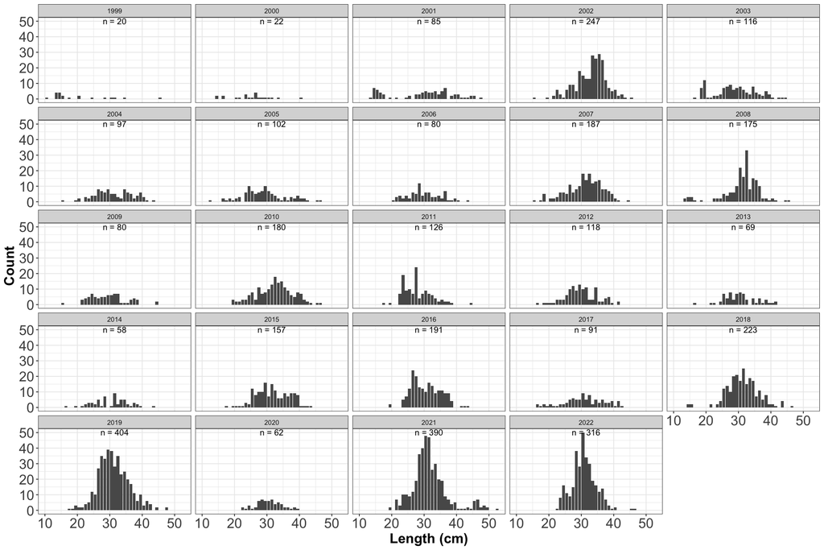

```r
# Object (think about it as a list) that keeps the context details of the plot about to be visualised
options(repr.plot.width = 15, repr.plot.height = 10)
plot_context <- PlotContext$new()
plot_context <- PlotContext$new()
plot_context$title_size <- 10
plot_context$face_text_size <- 2
plot_context$x_text_size <- 18
plot_context$y_text_size <- 18
plot_context$x_lab <- "Length (cm)"
plot_context$y_lab <- "Count"

g <- generate_yearly_length_distribution (catch_weight_data$catch_long,
                                          'MeanLength',
                                          'catch',
                                           plot_context)
g
```

- a) The **first two years** of the series have a very low representativeness with an average of **n=21** individuals
- b) The first **two/three** years do not conform an unimodal distribution. Instead it stretches out along the x-axis.

# 9. LBI Algorithm

## 9.1 LBI overview

[figure not shown]

1. **Inputs:**
   - A length frequency matrix
   - Biological parameters
2. **Outputs: (indicators need to be above a threshold)**
   - *Juvenile conservation (1,2)*: how does our length frequency matrix looks like with regards to the length of first sexual maturity?
   - *Adult conservation (3,4)*: How representative is our length frequency matrix when it comes to adults? Pmega less important
   - *Fisheries performance and MSY (4,5)*: all based on proxy lengths, it looks at the state of the fisheries by comparing the mean length above L<sub>c</sub> to L<sub>inf</sub>

## 9.2 Biological parameters loading

```r
bio_params <- BiologyParameters$new(
  linf = 48.4,
  k = 0.18,
  t0 = -0.58,
  l50 = 22.5,
  l95 = 23.115,
  M = 0.3105,
  M_K = 1.725,
  lwa = 0.021,
  lwb = 2.955,
  rec_variability_mean = 0.737, # Prior recruitment variability obtained from meta-analysis study
  rec_variability_sd = 0.353 # Prior fishing penalisation obtained from meta-analysis study
)

exp_params <- ExplotationParameters$new()
```

## 9.3 Run LBI algorithm

[figure not shown]

## 9.3.1 Common structure to run all algorithms

1. Create three lists or parameters, each containing data about biological, exploitation and matrices data
2. Not all list of parameters are required for all algorithms
3. The outputs are a vector of the years analised and a matrix where columns have the indicators and in the rows their values

```r
lbi_algo <- Lbi$new(bio_params, exp_params, catch_weight_data)
lbi_results <- lbi_algo$run()
data <- lbi_results$estimates
data$years <- lbi_results$years
head(data)
```

A data.frame: 6 × 7

|  | Lc_Lmat <dbl> | L25_Lmat <dbl> | Lmax5_Linf <dbl> | Pmega <dbl> | Lmean_Lopt <dbl> | Lmean_Lfem <dbl> | years <int> |
| --- | --- | --- | --- | --- | --- | --- | --- |
| 1 | 0.6000000 | 0.6000000 | 0.9400826 | 0.10000000 | 0.6790860 | 0.9777781 | 1999 |
| 2 | 0.6444444 | 0.9555556 | 0.8236169 | 0.04545455 | 0.8164914 | 1.1344125 | 2000 |
| 3 | 0.6444444 | 0.8666667 | 0.9437267 | 0.36470588 | 0.9684917 | 1.3455979 | 2001 |
| 4 | 1.3111111 | 1.3555556 | 0.8635443 | 0.47368421 | 1.1257064 | 1.0250672 | 2002 |
| 5 | 0.8222222 | 1.0888889 | 0.8624226 | 0.25000000 | 0.9435569 | 1.1497496 | 2003 |
| 6 | 1.0888889 | 1.1777778 | 0.8538175 | 0.37113402 | 1.0464993 | 1.0766068 | 2004 |

- **Along the columns** are laid the **indicators estimated**.
- **Each cell** for each row provides the value for a **single indicator per year**.

## 9.4 Plotting LBI estimates

The green dotted horizontal line show the treshold above which indicators are in good health. Then each yearly value showed as a dot is as well in gree if it is above such line and red if it is under it.

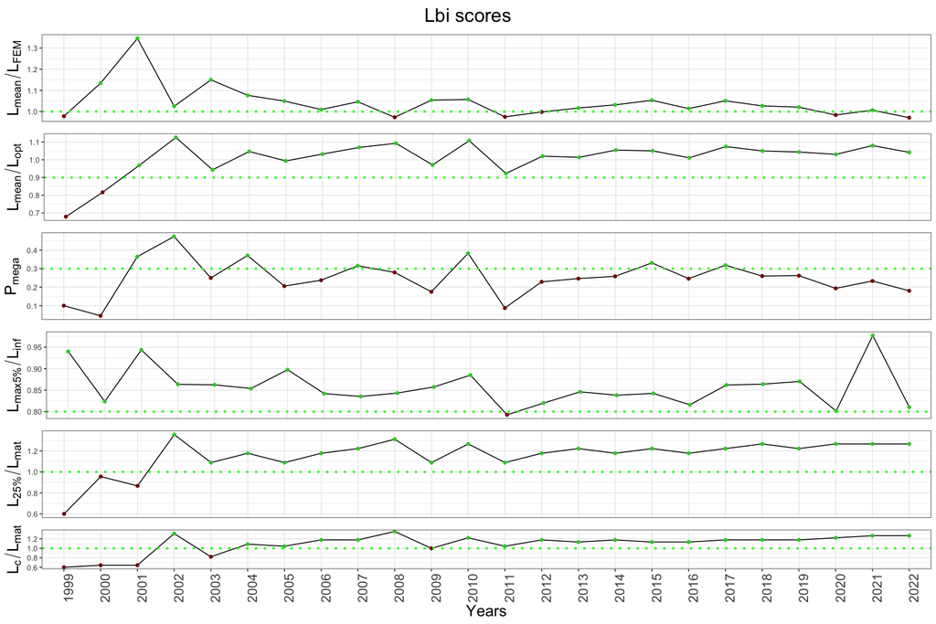

```r
# Threshold above which the corresponding indicators are showing a healthy status
options(repr.plot.width = 15, repr.plot.height = 10)
thresholds <- list(
  Lc_Lmat = 1,
  L25_Lmat = 1,
  Lmax5_Linf = 0.8,
  Pmega = 0.3,
  Lmean_Lopt = 0.9,
  Lmean_Lfem = 1)
lbi_plotter <- LbiOutputPlotter$new(data, thresholds)
grid <- lbi_plotter$generate_outputs(title_size = 22, title = "Lbi scores")
grid
```

Looking at the results, it seems that:

- a) In **1999 and 2000** the indicators about *juvenile conservation* seem to not doign well.
- b) Between **2001 and 2002** best indicators about *adult conservation*.
- c) Likewise between **2001 and 2003** best indicators about *fisheries performance*.